# prs_du_3

Islambek Ziyash, Oleksandr Popovych, Yehor Teroshyn

2025-05-28

## Úloha 1

Načteme data z databáze Eurostat

```r
raw_data <- get_eurostat("nama_10_fte")
```

```
## indexed 0B in  0s, 0B/sindexed 1.00TB in  0s, 3.05PB/s
```

```
## Table nama_10_fte cached at /var/folders/4n/d5s3tmx54ms5yzns5vlvhz280000gn/T//RtmppgQYpY/eurostat/fe855c757ed43ef4aed47c79ac1d13d5.rds
```

```r
raw_data
```

```
## # A tibble: 1,504 × 5
##    freq  unit  geo   TIME_PERIOD values
##    <chr> <chr> <chr> <date>       <dbl>
##  1 A     EUR   AT    1995-01-01   26543
##  2 A     EUR   AT    1996-01-01   26522
##  3 A     EUR   AT    1997-01-01   25943
##  4 A     EUR   AT    1998-01-01   26863
##  5 A     EUR   AT    1999-01-01   27714
##  6 A     EUR   AT    2000-01-01   28415
##  7 A     EUR   AT    2001-01-01   28890
##  8 A     EUR   AT    2002-01-01   29752
##  9 A     EUR   AT    2003-01-01   30237
## 10 A     EUR   AT    2004-01-01   31455
## # ℹ 1,494 more rows
```

Zobrazíme strukturu datasetu

```r
glimpse(raw_data)
```

```
## Rows: 1,504
## Columns: 5
## $ freq        <chr> "A", "A", "A", "A", "A", "A", "A", "A", "A", "A", "A", "A"…
## $ unit        <chr> "EUR", "EUR", "EUR", "EUR", "EUR", "EUR", "EUR", "EUR", "E…
## $ geo         <chr> "AT", "AT", "AT", "AT", "AT", "AT", "AT", "AT", "AT", "AT"…
## $ TIME_PERIOD <date> 1995-01-01, 1996-01-01, 1997-01-01, 1998-01-01, 1999-01-0…
## $ values      <dbl> 26543, 26522, 25943, 26863, 27714, 28415, 28890, 29752, 30…
```

Vidime ze data obsahují celkem 1504 řádků a 5 sloupců, kde:

- `freq` označuje frekvenci dat
- `unit` udává jednotku mzdy, v našem případě “EUR”
- `geo` obsahuje kód země
- `TIME_PERIOD` představuje časové období
- `values` obsahuje číselné hodnoty průměrné mzdy v eurech

Vyfiltrujeme data pro rok 2016 a jednotku EUR a pro prehlednost prejmenujeme kody zemi na jejich nazvy. Funkce “countrycode” nezna kody EA20 a EU27_2020 takze jsem to udelal rucne.

```r
data <- raw_data %>%
  filter(unit == "EUR", TIME_PERIOD == as.Date("2016-01-01")) %>%
  select(geo, salary = values) %>%
  mutate(
    geo = case_when(
      geo == "EA20" ~ "Euro area (EA20)",
      geo == "EU27_2020" ~ "European Union (EU27)",
      TRUE ~ countrycode(geo, "eurostat", "country.name")
    )
  ) %>%
  filter(!is.na(geo)) %>%
  select(geo, salary)
data
```

```
## # A tibble: 28 × 2
##    geo              salary
##    <chr>             <dbl>
##  1 Austria           42876
##  2 Belgium           45076
##  3 Bulgaria           6767
##  4 Cyprus            20759
##  5 Czechia           13141
##  6 Germany           40902
##  7 Denmark           57612
##  8 Euro area (EA20)  34411
##  9 Estonia           14540
## 10 Greece            16540
## # ℹ 18 more rows
```

0Podivame se na zakladni statistiky a zobrazime si par grafu

```r
summary(data$salary)
```

```
##    Min. 1st Qu.  Median    Mean 3rd Qu.    Max.
##    6767   13090   23002   26846   40923   62037
```

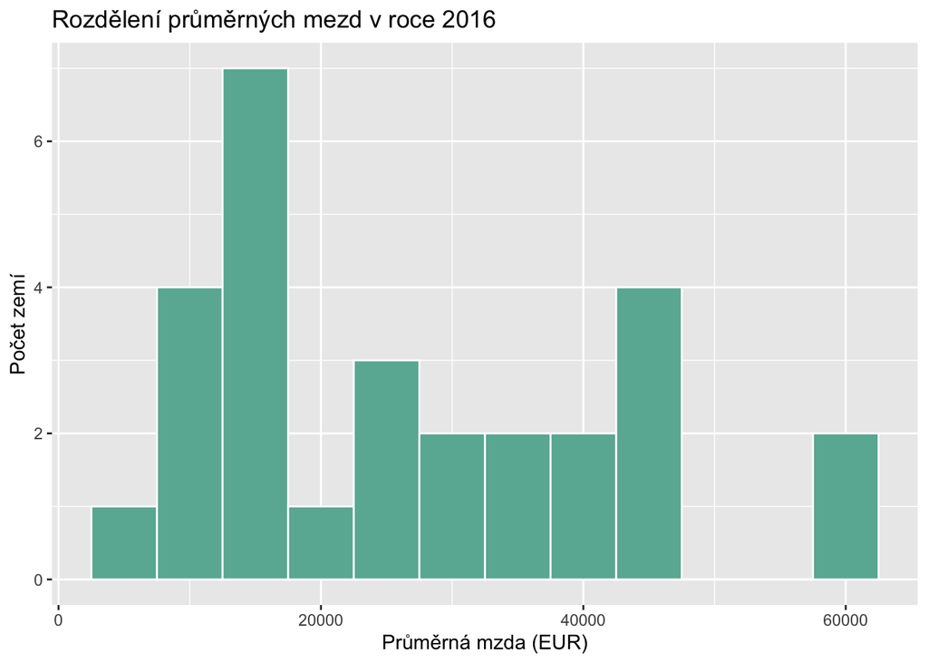

```r
ggplot(data, aes(x = salary)) +
  geom_histogram(binwidth = 5000, fill = "#69b3a2", color = "white") +
  labs(title = "Rozdělení průměrných mezd v roce 2016",
       x = "Průměrná mzda (EUR)",
       y = "Počet zemí")
```

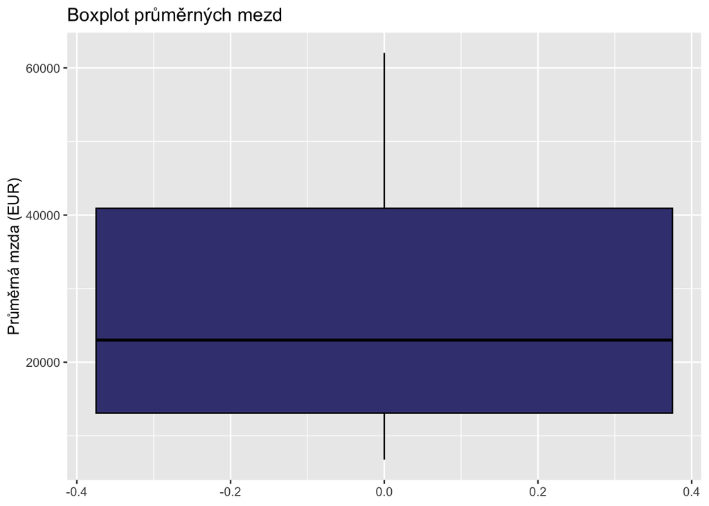

```r
ggplot(data, aes(y = salary)) +
  geom_boxplot(fill = "#404080", color = "black") +
  labs(title = "Boxplot průměrných mezd",
       y = "Průměrná mzda (EUR)")
```

### Interpretace výsledků a diskuse

#### Možné faktory ovlivňující průměrné mzdy:

- **Hospodářská vyspělost** dané země – HDP na obyvatele je často silně korelován s výší mezd
- **Daňový a sociální systém** – výše odvodů, přímých daní, podpory rodin, atd
- **Životní náklady** – vyšší mzdy často odpovídají vyšším nákladům (např. v západní Evropě)
- **Struktura ekonomiky** – státy s vyšším podílem znalostních a technologických odvětví mívají vyšší mzdy
- **Zaměstnanost a míra nezaměstnanosti** – nižší nezaměstnanost a větší poptávka po pracovní síle může zvyšovat mzdy

## Úloha 2

```r
raw_gdp <- get_eurostat("nama_10_pc", time_format = "date")
```

```
## indexed 0B in  0s, 0B/sindexed 1.00TB in  0s, 116.92TB/s
```

```
## Table nama_10_pc cached at /var/folders/4n/d5s3tmx54ms5yzns5vlvhz280000gn/T//RtmppgQYpY/eurostat/0a672d50b7fb49e8087c38510610f0c0.rds
```

```r
head(raw_gdp)
```

```
## # A tibble: 6 × 6
##   freq  unit          na_item geo   TIME_PERIOD values
##   <chr> <chr>         <chr>   <chr> <date>       <dbl>
## 1 A     CLV10_EUR_HAB B1GQ    AL    1995-01-01    1370
## 2 A     CLV10_EUR_HAB B1GQ    AL    1996-01-01    1480
## 3 A     CLV10_EUR_HAB B1GQ    AL    1997-01-01    1310
## 4 A     CLV10_EUR_HAB B1GQ    AL    1998-01-01    1430
## 5 A     CLV10_EUR_HAB B1GQ    AL    1999-01-01    1620
## 6 A     CLV10_EUR_HAB B1GQ    AL    2000-01-01    1750
```

```r
cols <- colnames(raw_gdp)

cols
```

```
## [1] "freq"        "unit"        "na_item"     "geo"         "TIME_PERIOD"
## [6] "values"
```

```r
unique_list <- lapply(cols, function(col) unique(raw_gdp[[col]]))

names(unique_list) <- cols

unique_list[1:4]
```

```
## $freq
## [1] "A"
##
## $unit
##  [1] "CLV10_EUR_HAB"            "CLV15_EUR_HAB"
##  [3] "CLV20_EUR_HAB"            "CLV_I10_HAB"
##  [5] "CLV_I15_HAB"              "CLV_I20_HAB"
##  [7] "CLV_PCH_PRE_HAB"          "CP_EUR_HAB"
##  [9] "CP_NAC_HAB"               "CP_PPS_EU27_2020_HAB"
## [11] "PC_EU27_2020_HAB_MEUR_CP" "PC_EU27_2020_HAB_MPPS_CP"
##
## $na_item
## [1] "B1GQ"        "P3"          "P31_S13"     "P31_S14"     "P31_S14_S15"
## [6] "P31_S15"     "P32_S13"     "P3_S13"      "P41"
##
## $geo
##  [1] "AL"        "AT"        "BE"        "BG"        "CH"        "CY"
##  [7] "CZ"        "DE"        "DK"        "EA"        "EA12"      "EA19"
## [13] "EA20"      "EE"        "EL"        "ES"        "EU27_2020" "FI"
## [19] "FR"        "HR"        "HU"        "IE"        "IS"        "IT"
## [25] "LT"        "LU"        "LV"        "ME"        "MK"        "MT"
## [31] "NL"        "NO"        "PL"        "PT"        "RO"        "RS"
## [37] "SE"        "SI"        "SK"        "TR"        "UK"        "LI"
## [43] "BA"        "XK"
```

```r
gdp_2016 <- raw_gdp %>%
  filter(TIME_PERIOD == as.Date("2016-01-01"),
         unit == "CP_PPS_EU27_2020_HAB",
         na_item == "B1GQ") %>%
  select(geo, gdp_per_capita = values)

head(gdp_2016)
```

```
## # A tibble: 6 × 2
##   geo   gdp_per_capita
##   <chr>          <dbl>
## 1 AL             8481.
## 2 AT            36386.
## 3 BE            33632.
## 4 BG            14412.
## 5 CY            24484
## 6 CZ            25444
```

```r
gdp_2016 <- gdp_2016 %>%
  mutate(geo = countrycode(geo, origin = "eurostat", destination = "country.name"))
head(gdp_2016)
```

```
## # A tibble: 6 × 2
##   geo      gdp_per_capita
##   <chr>             <dbl>
## 1 Albania           8481.
## 2 Austria          36386.
## 3 Belgium          33632.
## 4 Bulgaria         14412.
## 5 Cyprus           24484
## 6 Czechia          25444
```

Vybrali jsme data o HDP na obyvatele za rok 2016 ve standardních jednotkách kupní síly (PPS). Následně jsme převedli kódy zemí z formátu Eurostatu na jejich plné názvy pro lepší čitelnost a spojení s ostatními daty.

```r
euro_countries <- c("Austria", "Belgium", "Cyprus", "Estonia", "Finland", "France", "Germany",
                    "Greece", "Ireland", "Italy", "Latvia", "Lithuania", "Luxembourg", "Malta",
                    "Netherlands", "Portugal", "Slovakia", "Slovenia", "Spain")

data <- data %>%
  mutate(uses_euro = ifelse(geo %in% euro_countries, "Euro", "Other"))
```

Do datasetu jsme přidali novou kategorickou proměnnou `uses_euro`, která označuje, zda daná země používá euro jako svou měnu. Tato informace bude následně použita při analýze vlivu měny na průměrnou mzdu.

```r
monarchies <- c("Belgium", "Denmark", "Luxembourg", "Netherlands", "Spain",
                "Sweden", "United Kingdom", "Norway", "Liechtenstein")

data <- data %>%
  mutate(government_type = ifelse(geo %in% monarchies, "Monarchy", "Republic"))
```

Do datasetu jsme přidali novou kategorickou proměnnou `government_type`, která rozlišuje mezi monarchiemi a republikami. Tato proměnná nám umožní analyzovat vliv formy státního zřízení na průměrnou mzdu.

```r
edu_raw <- get_eurostat("educ_uoe_enra04")
```

```
## indexed 0B in  0s, 0B/sindexed 1.00TB in  0s, 1.99PB/s
```

```
## Table educ_uoe_enra04 cached at /var/folders/4n/d5s3tmx54ms5yzns5vlvhz280000gn/T//RtmppgQYpY/eurostat/d249a422b96b8a4bfc31c180cacbdb49.rds
```

```r
cols <- colnames(edu_raw)

cols
```

```
## [1] "freq"        "unit"        "isced11"     "geo"         "TIME_PERIOD"
## [6] "values"
```

```r
unique_list <- lapply(cols, function(col) unique(edu_raw[[col]]))

names(unique_list) <- cols

unique_list[1:4]
```

```
## $freq
## [1] "A"
##
## $unit
## [1] "PC"
##
## $isced11
##  [1] "ED0"    "ED0-8"  "ED02-8" "ED1"    "ED2"    "ED3"    "ED4"    "ED5"
##  [9] "ED6"    "ED7"    "ED8"
##
## $geo
##  [1] "AT"        "BE"        "BG"        "CH"        "CY"        "CZ"
##  [7] "DE"        "DK"        "EE"        "EL"        "ES"        "EU27_2020"
## [13] "FI"        "FR"        "HR"        "HU"        "IE"        "IS"
## [19] "IT"        "LI"        "LT"        "LU"        "LV"        "ME"
## [25] "MK"        "MT"        "NL"        "NO"        "PL"        "PT"
## [31] "RO"        "RS"        "SE"        "SI"        "SK"        "TR"
## [37] "UK"        "AL"        "EU28"
```

```r
edu_raw
```

```
## # A tibble: 4,266 × 6
##    freq  unit  isced11 geo   TIME_PERIOD values
##    <chr> <chr> <chr>   <chr> <date>       <dbl>
##  1 A     PC    ED0     AT    2013-01-01     3.2
##  2 A     PC    ED0     AT    2014-01-01     3.3
##  3 A     PC    ED0     AT    2015-01-01     3.4
##  4 A     PC    ED0     AT    2016-01-01     3.5
##  5 A     PC    ED0     AT    2017-01-01     3.5
##  6 A     PC    ED0     AT    2018-01-01     3.6
##  7 A     PC    ED0     AT    2019-01-01     3.6
##  8 A     PC    ED0     AT    2020-01-01     3.7
##  9 A     PC    ED0     AT    2021-01-01     3.7
## 10 A     PC    ED0     AT    2022-01-01     3.7
## # ℹ 4,256 more rows
```

```r
higher_edu <- edu_raw %>%
  filter(
    TIME_PERIOD == as.Date("2016-01-01"),
    unit == "PC",
    isced11 %in% c("ED5", "ED6", "ED7", "ED8")
  ) %>%
  group_by(geo) %>%
  summarise(higher = sum(values, na.rm = TRUE))

total_edu <- edu_raw %>%
  filter(
    TIME_PERIOD == as.Date("2016-01-01"),
    unit == "PC",
    isced11 == "ED0-8"
  ) %>%
  select(geo, total = values)

edu_data <- higher_edu %>%
  inner_join(total_edu, by = "geo") %>%
  mutate(tertiary_edu = higher / total) %>%
  mutate(geo = countrycode(geo, "eurostat", "country.name")) %>%
  filter(!is.na(geo))
head(edu_data)
```

```
## # A tibble: 6 × 4
##   geo         higher total tertiary_edu
##   <chr>        <dbl> <dbl>        <dbl>
## 1 Austria        5    20.3        0.246
## 2 Belgium        4.5  27.7        0.162
## 3 Bulgaria       3.9  18          0.217
## 4 Switzerland    3.6  19.1        0.188
## 5 Cyprus         4.7  21.4        0.220
## 6 Czechia        3.5  20.1        0.174
```

```r
edu_data <- edu_data %>%
  select(-higher, -total)

edu_data
```

```
## # A tibble: 31 × 2
##    geo         tertiary_edu
##    <chr>              <dbl>
##  1 Austria            0.246
##  2 Belgium            0.162
##  3 Bulgaria           0.217
##  4 Switzerland        0.188
##  5 Cyprus             0.220
##  6 Czechia            0.174
##  7 Germany            0.176
##  8 Denmark            0.195
##  9 Estonia            0.173
## 10 Spain              0.192
## # ℹ 21 more rows
```

Z původních dat o vzdělání jsme vybrali podíl osob s dosaženým terciárním vzděláním (ISCED úrovně 5 až 8) pro rok 2016. Procentuální podíly jsme agregovali podle zemí a upravili kódy zemí na jejich názvy.

```r
merged_data <- data %>%
  left_join(edu_data, by = "geo")

head(merged_data)
```

```
## # A tibble: 6 × 5
##   geo      salary uses_euro government_type tertiary_edu
##   <chr>     <dbl> <chr>     <chr>                  <dbl>
## 1 Austria   42876 Euro      Republic               0.246
## 2 Belgium   45076 Euro      Monarchy               0.162
## 3 Bulgaria   6767 Other     Republic               0.217
## 4 Cyprus    20759 Euro      Republic               0.220
## 5 Czechia   13141 Other     Republic               0.174
## 6 Germany   40902 Euro      Republic               0.176
```

```r
merged_data <- merged_data %>%
  left_join(gdp_2016, by = "geo")
head(merged_data)
```

```
## # A tibble: 6 × 6
##   geo      salary uses_euro government_type tertiary_edu gdp_per_capita
##   <chr>     <dbl> <chr>     <chr>                  <dbl>          <dbl>
## 1 Austria   42876 Euro      Republic               0.246         36386.
## 2 Belgium   45076 Euro      Monarchy               0.162         33632.
## 3 Bulgaria   6767 Other     Republic               0.217         14412.
## 4 Cyprus    20759 Euro      Republic               0.220         24484
## 5 Czechia   13141 Other     Republic               0.174         25444
## 6 Germany   40902 Euro      Republic               0.176         35824.
```

```r
merged_data <- merged_data %>%
  mutate(tertiary_edu = tertiary_edu * 100)
head(merged_data)
```

```
## # A tibble: 6 × 6
##   geo      salary uses_euro government_type tertiary_edu gdp_per_capita
##   <chr>     <dbl> <chr>     <chr>                  <dbl>          <dbl>
## 1 Austria   42876 Euro      Republic                24.6         36386.
## 2 Belgium   45076 Euro      Monarchy                16.2         33632.
## 3 Bulgaria   6767 Other     Republic                21.7         14412.
## 4 Cyprus    20759 Euro      Republic                22.0         24484
## 5 Czechia   13141 Other     Republic                17.4         25444
## 6 Germany   40902 Euro      Republic                17.6         35824.
```

### Výběr proměnných

Pro analýzu jsme vybrali čtyři proměnné dostupné z databází Eurostatu a dalších zdrojů:

**salary** – průměrná mzda v roce 2016 (numerická, závislá proměnná),

**gdp_per_capita** – HDP na obyvatele v roce 2016 (numerická),

**tertiary_edu** – podíl obyvatel s terciárním vzděláním (numerická),

**uses_euro** – zda země používá euro jako měnu (kategoriální: Euro / Other),

**government_type** – typ vlády (kategoriální: Monarchie / Republika).

Vybrané proměnné mají logickou souvislost s úrovní mezd – HDP a vzdělání ovlivňují ekonomickou výkonnost a produktivitu, zatímco měnová politika a forma vlády mohou ovlivnit ekonomické podmínky a stabilitu.

```r
summary(merged_data)
```

```
##      geo                salary       uses_euro         government_type
##  Length:28          Min.   : 6767   Length:28          Length:28
##  Class :character   1st Qu.:13090   Class :character   Class :character
##  Mode  :character   Median :23002   Mode  :character   Mode  :character
##                     Mean   :26846
##                     3rd Qu.:40923
##                     Max.   :62037
##
##   tertiary_edu    gdp_per_capita
##  Min.   : 6.349   Min.   :14412
##  1st Qu.:16.679   1st Qu.:19968
##  Median :17.561   Median :24964
##  Mean   :18.042   Mean   :28234
##  3rd Qu.:20.189   3rd Qu.:32963
##  Max.   :24.631   Max.   :78467
##  NA's   :5        NA's   :2
```

```r
cor(merged_data %>% select(salary, gdp_per_capita, tertiary_edu), use = "complete.obs")
```

```
##                    salary gdp_per_capita tertiary_edu
## salary          1.0000000      0.8334259   -0.3395319
## gdp_per_capita  0.8334259      1.0000000   -0.6294644
## tertiary_edu   -0.3395319     -0.6294644    1.0000000
```

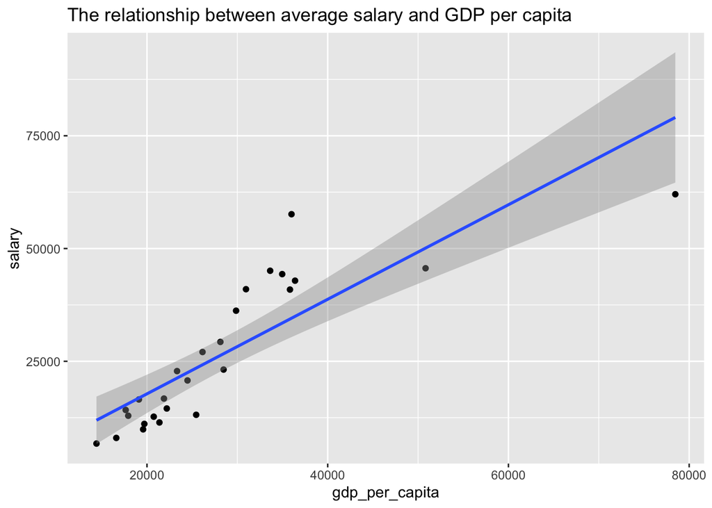

```r
ggplot(merged_data, aes(x = gdp_per_capita, y = salary)) +
  geom_point() +
  geom_smooth(method = "lm") +
  labs(title = "The relationship between average salary and GDP per capita")
```

Graf s regresní přímkou ukazuje silně pozitivní vztah mezi HDP na obyvatele a průměrnou mzdou. Většina bodů leží blízko modré čáry, což potvrzuje vysokou korelaci a význam této proměnné v regresním modelu. Šedé pásmo reprezentuje interval spolehlivosti a ukazuje relativně nízkou nejistotu v centrální části dat. Tento vztah je klíčovým výsledkem celé analýzy.

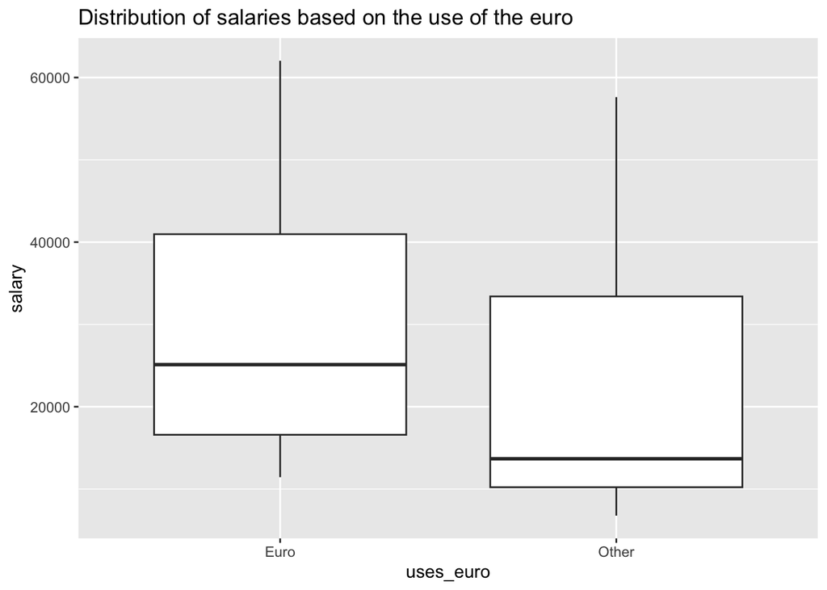

```r
ggplot(merged_data, aes(x = uses_euro, y = salary)) +
  geom_boxplot() +
  labs(title = "Distribution of salaries based on the use of the euro")
```

Vidíme, že země s eurem mají obecně vyšší medián mezd i větší rozptyl, ale rozdíly nejsou extrémní. Překrývání rozmezí naznačuje, že používání eura nemusí být klíčovým faktorem pro vysvětlení rozdílů v platech. To odpovídá i regresní analýze, kde proměnná uses_euro nebyla statisticky významná.

```r
model <- lm(salary ~ gdp_per_capita + tertiary_edu + uses_euro + government_type, data = merged_data)
model
```

```
##
## Call:
## lm(formula = salary ~ gdp_per_capita + tertiary_edu + uses_euro +
##     government_type, data = merged_data)
##
## Coefficients:
##             (Intercept)           gdp_per_capita             tertiary_edu
##              -19563.665                    1.065                 1493.330
##          uses_euroOther  government_typeRepublic
##               -1704.935               -12885.517
```

```r
summary(model)
```

```
##
## Call:
## lm(formula = salary ~ gdp_per_capita + tertiary_edu + uses_euro +
##     government_type, data = merged_data)
##
## Residuals:
##      Min       1Q   Median       3Q      Max
## -11427.2  -5685.0   -709.1   4923.8  13603.8
##
## Coefficients:
##                            Estimate  Std. Error t value  Pr(>|t|)
## (Intercept)             -19563.6654  17060.9004  -1.147    0.2665
## gdp_per_capita               1.0647      0.2071   5.142 0.0000683 ***
## tertiary_edu              1493.3296    624.3470   2.392    0.0279 *
## uses_euroOther           -1704.9349   3812.7286  -0.447    0.6601
## government_typeRepublic -12885.5166   5073.0736  -2.540    0.0205 *
## ---
## Signif. codes:  0 '***' 0.001 '**' 0.01 '*' 0.05 '.' 0.1 ' ' 1
##
## Residual standard error: 7836 on 18 degrees of freedom
##   (5 observations deleted due to missingness)
## Multiple R-squared:  0.8175, Adjusted R-squared:  0.7769
## F-statistic: 20.15 on 4 and 18 DF,  p-value: 0.000001881
```

## Interpretace výsledků regresního modelu

Byl vytvořen lineární regresní model, který vysvětluje průměrnou mzdu (**salary**) na základě těchto proměnných: HDP na obyvatele (**gdp_per_capita**), podíl populace s terciárním vzděláním (**tertiary_edu**), používání eura (**uses_euro**) a typ vlády (**government_type**).

### Shrnutí modelu

Model vysvětluje přibližně 81,75 % variability průměrné mzdy mezi zeměmi (Adjusted R-squared = 0,7769). To znamená, že zvolené proměnné dobře zachycují rozdíly v platech mezi sledovanými zeměmi.

### Interpretace koeficientů

**Intercept (-19563,67)**: Odhadovaná průměrná mzda, pokud by všechny nezávislé proměnné byly nulové. Tento odhad není statisticky významný (p = 0,266), proto ho nelze prakticky interpretovat.

**gdp_per_capita (1,065)**: Koeficient je vysoce statisticky významný (p < 0,001). Znamená to, že s každým zvýšením HDP na obyvatele o 1 jednotku vzroste průměrná mzda přibližně o 1,07 jednotky. HDP je tedy silným pozitivním prediktorem mzdy.

**tertiary_edu (1493,33)**: Tento koeficient je také statisticky významný (p = 0,028). Znamená to, že s každým zvýšením podílu populace s terciárním vzděláním o 1 % se průměrná mzda zvýší o cca 1493.

**uses_euroOther (-1704,93)**: Koeficient není statisticky významný (p = 0,660), což znamená, že používání eura nemá statisticky významný vliv na průměrnou mzdu v tomto modelu.

**government_typeRepublic (-12885,52)**: Tento koeficient je statisticky významný (p = 0,021) a ukazuje, že v republikách jsou průměrné mzdy o přibližně 12 885 nižší než v monarchiích, ostatní faktory při tom zůstávají konstantní.

### Závěr

Model potvrzuje, že ekonomická úroveň země (měřená HDP na obyvatele) a vzdělání populace jsou klíčové faktory ovlivňující průměrné mzdy. Typ vlády také významně souvisí s výší mezd, přičemž monarchie vykazují vyšší mzdy než republiky. Naopak, používání eura nemá ve sledovaných datech významný efekt na mzdy.

Celkově model dobře vysvětluje rozdíly v průměrných mzdách mezi evropskými zeměmi.

```r
table_government_uses <- table(merged_data$government_type, merged_data$uses_euro)
chisq.test(table_government_uses)
```

```
##
##  Pearson's Chi-squared test with Yates' continuity correction
##
## data:  table_government_uses
## X-squared = 0.00000000000000000000000000000049391, df = 1, p-value = 1
```

```r
t.test(salary ~ uses_euro, data = merged_data)
```

```
##
##  Welch Two Sample t-test
##
## data:  salary by uses_euro
## t = 0.91247, df = 15.944, p-value = 0.3751
## alternative hypothesis: true difference in means between group Euro and group Other is not equal to 0
## 95 percent confidence interval:
##  -7936.667 19926.445
## sample estimates:
##  mean in group Euro mean in group Other
##            28987.39            22992.50
```

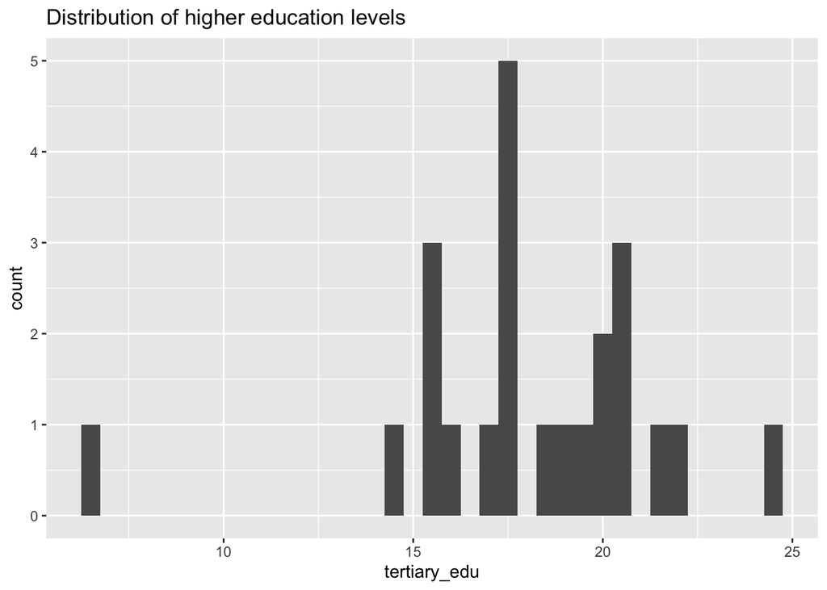

```r
ggplot(merged_data, aes(x = tertiary_edu)) + geom_histogram(binwidth = 0.5) +
  labs(title = "Distribution of higher education levels")
```

```r
table(merged_data$government_type)
```

```
##
## Monarchy Republic
##        5       23
```

Histogram ukazuje rozdělení hodnot proměnné tertiary_edu mezi státy. Většina zemí má podíl vysokoškolsky vzdělaných obyvatel mezi 15 % a 22 %, přičemž nejčastější hodnota se pohybuje okolo 18 %. Rozdělení není zcela normální a obsahuje i několik odlehlých pozorování. To může částečně vysvětlovat, proč proměnná tertiary_edu nevykazuje silný lineární vztah se mzdami.

## Interpretace výsledků statistických testů

### Test nezávislosti (Pearsonův chí-kvadrát)

Byl proveden test nezávislosti mezi dvěma kategoriálními proměnnými: **government_type** (typ vlády: monarchie vs. republika) a **uses_euro** (používání eura ano/ne). Výsledek testu:

Hodnota chí-kvadrát statistiky je extrémně blízká nule (X² ≈ 0),

p-hodnota je 1, což znamená, že nemáme žádný důvod zamítat hypotézu o nezávislosti těchto proměnných.

**Závěr:** Typ vlády a používání eura spolu nejsou statisticky závislé.

### Welchův t-test pro rozdíl průměrů mezd podle používání eura

Byl proveden Welchův t-test pro porovnání průměrných mezd (**salary**) mezi skupinami zemí používajících euro a těch, které euro nepoužívají.

t-statistika: 0,912

stupně volnosti: přibližně 16

p-hodnota: 0,3751 (větší než 0,05)

95% interval spolehlivosti pro rozdíl průměrů: od -7937 do 19926

Průměrné mzdy:

Země používající euro: 28 987

Země nepoužívající euro: 22 993

**Závěr:** Neexistuje statisticky významný rozdíl v průměrných mzdách mezi zeměmi používajícími euro a těmi, které euro nepoužívají.

## Úloha 3

### 1. Výchozí model se všemi proměnnými

```r
model <- lm(salary ~ gdp_per_capita + tertiary_edu + uses_euro + government_type, data = merged_data)
summary(model)
```

```
##
## Call:
## lm(formula = salary ~ gdp_per_capita + tertiary_edu + uses_euro +
##     government_type, data = merged_data)
##
## Residuals:
##      Min       1Q   Median       3Q      Max
## -11427.2  -5685.0   -709.1   4923.8  13603.8
##
## Coefficients:
##                            Estimate  Std. Error t value  Pr(>|t|)
## (Intercept)             -19563.6654  17060.9004  -1.147    0.2665
## gdp_per_capita               1.0647      0.2071   5.142 0.0000683 ***
## tertiary_edu              1493.3296    624.3470   2.392    0.0279 *
## uses_euroOther           -1704.9349   3812.7286  -0.447    0.6601
## government_typeRepublic -12885.5166   5073.0736  -2.540    0.0205 *
## ---
## Signif. codes:  0 '***' 0.001 '**' 0.01 '*' 0.05 '.' 0.1 ' ' 1
##
## Residual standard error: 7836 on 18 degrees of freedom
##   (5 observations deleted due to missingness)
## Multiple R-squared:  0.8175, Adjusted R-squared:  0.7769
## F-statistic: 20.15 on 4 and 18 DF,  p-value: 0.000001881
```

Tento model vysvětluje přibližně 78 % variability mezd (Adjusted R² = 0.777), což značí solidní kvalitu. Statisticky významné jsou proměnné HDP na obyvatele (p < 0.001), podíl vysokoškolsky vzdělaných osob (p < 0.05) a forma vlády (p < 0.05). Proměnná „uses_euro“ není významná (p = 0.66), stejně jako konstanta (průsečík). Vzhledem k vysokému standardnímu odhadu by model mohl být dále optimalizován.

### 2. Krokový výběr proměnných (Stepwise AIC)

```r
library(MASS)
step_model <- stepAIC(model, direction = "both")
```

```
## Start:  AIC=416.82
## salary ~ gdp_per_capita + tertiary_edu + uses_euro + government_type
##
##                   Df  Sum of Sq        RSS    AIC
## - uses_euro        1   12278137 1117529724 415.07
## <none>                          1105251587 416.82
## - tertiary_edu     1  351275560 1456527147 421.17
## - government_type  1  396141175 1501392762 421.87
## - gdp_per_capita   1 1623503953 2728755540 435.61
##
## Step:  AIC=415.07
## salary ~ gdp_per_capita + tertiary_edu + government_type
##
##                   Df  Sum of Sq        RSS    AIC
## <none>                          1117529724 415.07
## + uses_euro        1   12278137 1105251587 416.82
## - government_type  1  388064458 1505594181 419.93
## - tertiary_edu     1  396438011 1513967735 420.06
## - gdp_per_capita   1 2147908601 3265438325 437.74
```

```r
summary(step_model)
```

```
##
## Call:
## lm(formula = salary ~ gdp_per_capita + tertiary_edu + government_type,
##     data = merged_data)
##
## Residuals:
##      Min       1Q   Median       3Q      Max
## -11685.3  -6021.0   -878.5   5025.3  14126.9
##
## Coefficients:
##                            Estimate  Std. Error t value  Pr(>|t|)
## (Intercept)             -22811.5496  15109.1056  -1.510    0.1475
## gdp_per_capita               1.1047      0.1828   6.043 0.0000082 ***
## tertiary_edu              1551.5486    597.6274   2.596    0.0177 *
## government_typeRepublic -12261.5269   4773.5927  -2.569    0.0188 *
## ---
## Signif. codes:  0 '***' 0.001 '**' 0.01 '*' 0.05 '.' 0.1 ' ' 1
##
## Residual standard error: 7669 on 19 degrees of freedom
##   (5 observations deleted due to missingness)
## Multiple R-squared:  0.8154, Adjusted R-squared:  0.7863
## F-statistic: 27.98 on 3 and 19 DF,  p-value: 0.0000003522
```

Pomocí metody stepAIC byl z modelu automaticky odstraněn prediktor uses_euro, protože jeho odstranění snížilo AIC z 416.82 na 415.07. To naznačuje, že proměnná uses_euro nepřispívala ke kvalitě modelu. Výsledný model obsahuje pouze tři prediktory: HDP na obyvatele, podíl vysokoškolsky vzdělaných a typ vlády. Optimalizovaný model je tedy jednodušší a statisticky lepší.

### 3. Diagnostika vícenásobné kolinearity

```r
vif(step_model)
```

```
##  gdp_per_capita    tertiary_edu government_type
##        2.086437        1.664965        1.516003
```

Diagnostika vícenásobné kolinearity pomocí VIF (Variance Inflation Factor) slouží k odhalení, zda nejsou prediktory v modelu příliš silně vzájemně korelované. Vysoká kolinearita může způsobit nestabilní odhady koeficientů a ztížit interpretaci modelu. V našem případě jsou všechny hodnoty VIF (skoro) pod 2, což značí, že mezi proměnnými není výrazná kolinearita. Model je tedy z hlediska této diagnostiky spolehlivý.

### 4. Diagnostické grafy

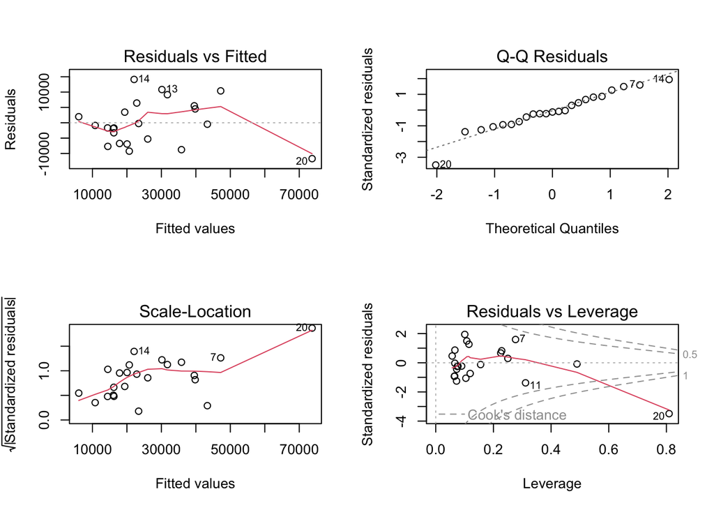

```r
par(mfrow = c(2, 2))
plot(step_model)
```

- Residuals vs Fitted Rezidua jsou rozprostřena víceméně náhodně, ale u vyšších hodnot dochází k odchylce směrem dolů. Pozorování č. 20 má extrémní negativní reziduum a působí jako odlehlý bod.
- Q-Q Plot (Normalita reziduí) Většina bodů leží blízko přímky, což značí přibližně normální rozdělení reziduí. Pozorování č. 20 opět výrazně vybočuje a narušuje normalitu.
- Scale-Location Červená čára naznačuje mírný nárůst rozptylu reziduí, což může ukazovat na slabou heteroskedasticitu. Největší odchylku má opět pozorování č. 20.
- Residuals vs Leverage Pozorování č. 20 má vysoky leverage a zároveň velké reziduum, což z něj dělá velmi vlivný bod. Mělo by být zváženo jeho odstranění nebo další analýza.

### 5. Test normality reziduí

```r
shapiro.test(residuals(step_model))
```

```
##
##  Shapiro-Wilk normality test
##
## data:  residuals(step_model)
## W = 0.96787, p-value = 0.6381
```

Hodnota p = 0.6381 je výrazně vyšší než hladina významnosti 0.05, takže neodmítáme nulovou hypotézu o normalitě. To znamená, že rezidua jsou v souladu s předpokladem normálního rozdělení. Výsledek podporuje platnost modelu z hlediska této podmínky lineární regrese.

### 6. Test homoskedasticity (Breusch-Pagan)

```r
bptest(step_model)
```

```
##
##  studentized Breusch-Pagan test
##
## data:  step_model
## BP = 5.1659, df = 3, p-value = 0.16
```

p-hodnota testu Breusch-Pagan je 0.16, což je více než 0.05, takže neodmítáme nulovou hypotézu o konstantní varianci reziduí. To znamená, že v modelu nebyla zjištěna významná heteroskedasticita. Předpoklad homoskedasticity je tedy splněn a model je v tomto ohledu v pořádku.

### 7. Identifikace vlivného pozorování pomocí Cookovy vzdálenosti

```r
influential_index <- which.max(cooks.distance(step_model))
influential_row <- as.numeric(rownames(step_model$model))[influential_index]
merged_data[influential_row, ]
```

```
## # A tibble: 1 × 6
##   geo        salary uses_euro government_type tertiary_edu gdp_per_capita
##   <chr>       <dbl> <chr>     <chr>                  <dbl>          <dbl>
## 1 Luxembourg  62037 Euro      Monarchy                6.35         78467.
```

```r
data_no20 <- merged_data[-influential_row, ]
```

Pomocí Cookovy vzdálenosti bylo identifikováno vlivné pozorování – konkrétně Lucembursko. Má výrazně vyšší HDP na obyvatele i mzdu než ostatní země, a proto výrazně ovlivňuje odhady modelu. Z důvodu jeho extrémní hodnoty bylo rozhodnuto toto pozorování z analýzy odstranit. Nový dataset data_no20 bude použit pro robustnější modelování.

### 8. Model bez vlivného pozorování

```r
model_no20 <- lm(salary ~ gdp_per_capita + tertiary_edu + government_type, data = data_no20)
summary(model_no20)
```

```
##
## Call:
## lm(formula = salary ~ gdp_per_capita + tertiary_edu + government_type,
##     data = data_no20)
##
## Residuals:
##    Min     1Q Median     3Q    Max
##  -9520  -2420  -1048   2910   7241
##
## Coefficients:
##                            Estimate  Std. Error t value      Pr(>|t|)
## (Intercept)             -23635.7624   9305.4687  -2.540        0.0205 *
## gdp_per_capita               1.8406      0.1719  10.709 0.00000000308 ***
## tertiary_edu               397.7363    420.6087   0.946        0.3569
## government_typeRepublic  -7461.3409   3059.2716  -2.439        0.0253 *
## ---
## Signif. codes:  0 '***' 0.001 '**' 0.01 '*' 0.05 '.' 0.1 ' ' 1
##
## Residual standard error: 4723 on 18 degrees of freedom
##   (5 observations deleted due to missingness)
## Multiple R-squared:  0.9151, Adjusted R-squared:  0.901
## F-statistic: 64.68 on 3 and 18 DF,  p-value: 0.0000000007753
```

Po odstranění vlivného pozorování (Lucemburska) se kvalita modelu výrazně zlepšila – Adjusted R² vzrostlo na 0.901. HDP na obyvatele zůstává silně statisticky významným prediktorem (p < 0.001) a typ vlády je také významný (p < 0.05). Proměnná tertiary_edu však ztratila statistickou významnost (p = 0.3569), což naznačuje, že nemá výrazný vliv na mzdy ve zbytku dat.

### 9. Alternativní model bez proměnné tertiary_edu

Zkusme se ještě podívat, jak se náš model chová bez proměnné tertiary_edu.

```r
model_no_ter <- lm(salary ~ gdp_per_capita + government_type, data = data_no20)
summary(model_no_ter)
```

```
##
## Call:
## lm(formula = salary ~ gdp_per_capita + government_type, data = data_no20)
##
## Residuals:
##      Min       1Q   Median       3Q      Max
## -12090.9  -2992.4      9.1   3444.1  11152.8
##
## Coefficients:
##                           Estimate Std. Error t value    Pr(>|t|)
## (Intercept)              -2344.003   5691.455  -0.412     0.68444
## gdp_per_capita               1.403      0.150   9.355 0.000000004 ***
## government_typeRepublic -11264.498   3358.512  -3.354     0.00287 **
## ---
## Signif. codes:  0 '***' 0.001 '**' 0.01 '*' 0.05 '.' 0.1 ' ' 1
##
## Residual standard error: 5782 on 22 degrees of freedom
##   (2 observations deleted due to missingness)
## Multiple R-squared:  0.8611, Adjusted R-squared:  0.8485
## F-statistic:  68.2 on 2 and 22 DF,  p-value: 0.0000000003707
```

Po odstranění proměnné tertiary_edu se model stal jednodušším, ale došlo k mírnému snížení přesnosti – Adjusted R² kleslo z 0.901 na 0.8485. I přesto si model zachovává vysokou vysvětlovací schopnost. Proměnná HDP na obyvatele zůstává silně významná a typ vlády také. Ztráta proměnné tertiary_edu tedy nevede k dramatickému zhoršení modelu, ale mírný pokles výkonu je patrný.

### 10. Důvěryhodné intervaly pro koeficienty modelu

```r
confint(model_no20)
```

```
##                                 2.5 %       97.5 %
## (Intercept)             -43185.826612 -4085.698200
## gdp_per_capita               1.479491     2.201688
## tertiary_edu              -485.929862  1281.402431
## government_typeRepublic -13888.631995 -1034.049817
```

Intervaly spolehlivosti ukazují, že koeficienty proměnných gdp_per_capita a government_typeRepublic jsou statisticky významné, protože jejich intervaly neobsahují nulu. Naopak interval pro tertiary_edu zahrnuje nulu (od -486 do 1281), což potvrzuje, že tato proměnná není spolehlivým prediktorem. Výsledky odpovídají p-hodnotám z regresního modelu a podporují úvahu o možném vyřazení této proměnné.

### 11. Výběr finálního modelu

Pro finální model vybrali jsme ponechat model model_no20, který má vyšší vysvětlovací sílu (Adjusted R² = 0.901). Ačkoli proměnná tertiary_edu není statisticky významná, byla ponechána z důvodu jejího potenciálního vysvětlujícího významu. V případě důrazu na predikci lze však alternativně zvolit zjednodušený model model_no_ter

### 11. Praktická interpretace

Výsledky regresní analýzy ukazují, že nejdůležitějším faktorem ovlivňujícím průměrnou mzdu ve zkoumaných evropských zemích je HDP na obyvatele. Každé zvýšení HDP o 1 000 € vede přibližně k nárůstu mezd o 1 840 €, což potvrzuje silnou ekonomickou závislost.

Dále byl významným faktorem také typ vlády – v průměru jsou mzdy v republikách o zhruba 7 500 € nižší než v monarchiích, při zachování ostatních proměnných konstantních. Tento výsledek může odrážet odlišnosti ve struktuře ekonomiky nebo velikosti států.

Naopak proměnná podíl vysokoškolsky vzdělaných osob se ukázala jako statisticky nevýznamná, což znamená, že ve zkoumaném vzorku sama o sobě nevysvětluje rozdíly v mzdách mezi zeměmi. Může to být způsobeno tím, že efekt vzdělání se již odráží v HDP nebo že závislost není lineární.

Model jako celek vykazuje velmi dobrou vysvětlovací sílu (Adjusted R² = 0.901), což znamená, že zvolené proměnné dobře popisují variabilitu mezd mezi státy. Po odstranění extrémního vlivu Lucemburska se model stal stabilnějším a přesnějším.